# R Data Analysis Portfolio Demonstration

Onyinyechukwu Rowland Olebunne

2026-10-24

## Purpose and data notice

This is a portfolio demonstration of an R analysis workflow. It uses **fully synthetic data generated in this file**. It does not contain the original capstone dataset, student records, original report findings, or institutional attribution. The example is illustrative; results must not be interpreted as evidence about real students or schools.

## 1. Setup

```r
library(tidyverse)
library(janitor)
library(effectsize)
library(car)

set.seed(2026)
theme_set(theme_minimal(base_size = 12))
```

## 2. Create synthetic demonstration data

```r
n <- 120
survey_demo <- tibble(
  study_id = sprintf("DEMO%03d", seq_len(n)),
  migration_status = sample(c("Migrant", "Non-migrant"), n, replace = TRUE),
  sex = sample(c("Female", "Male"), n, replace = TRUE),
  age = sample(12:18, n, replace = TRUE),
  social_support = pmin(10, pmax(1, round(rnorm(n, 6, 2)))),
  sense_of_belonging = pmin(10, pmax(1, round(rnorm(n, 6, 2)))),
  study_hours = pmax(0, round(rnorm(n, 2.5, 1.1), 1))
)

academic_demo <- tibble(
  study_id = sample(survey_demo$study_id),
  exam_score = pmin(100, pmax(0, round(rnorm(n, 65, 12))))
)

# Example of basic structure checks
 dim(survey_demo)
```

```
## [1] 120   7
```

```r
 names(survey_demo)
```

```
## [1] "study_id"           "migration_status"
## [3] "sex"                "age"
## [5] "social_support"     "sense_of_belonging"
## [7] "study_hours"
```

```r
 glimpse(survey_demo)
```

```
## Rows: 120
## Columns: 7
## $ study_id           <chr> "DEMO001", "DEMO002", "DEMO003", …
## $ migration_status   <chr> "Migrant", "Migrant", "Migrant", …
## $ sex                <chr> "Male", "Male", "Female", "Male",…
## $ age                <int> 12, 16, 17, 15, 17, 17, 16, 17, 1…
## $ social_support     <dbl> 5, 7, 5, 10, 7, 4, 9, 5, 3, 4, 6,…
## $ sense_of_belonging <dbl> 7, 2, 5, 8, 9, 2, 1, 3, 3, 7, 7, …
## $ study_hours        <dbl> 1.8, 2.0, 3.3, 4.8, 2.5, 3.5, 0.2…
```

## 3. Merge and validate datasets

```r
analysis_data <- survey_demo %>%
  left_join(academic_demo, by = "study_id") %>%
  clean_names()

# Check key uniqueness and missingness
stopifnot(nrow(analysis_data) == n)
stopifnot(!anyDuplicated(analysis_data$study_id))

analysis_data %>%
  summarise(
    records = n(),
    missing_exam_scores = sum(is.na(exam_score)),
    unique_ids = n_distinct(study_id)
  )
```

```
## # A tibble: 1 × 3
##   records missing_exam_scores unique_ids
##     <int>               <int>      <int>
## 1     120                   0        120
```

## 4. Descriptive statistics

```r
analysis_data %>%
  summarise(
    mean_exam_score = mean(exam_score, na.rm = TRUE),
    sd_exam_score = sd(exam_score, na.rm = TRUE),
    mean_social_support = mean(social_support, na.rm = TRUE),
    mean_study_hours = mean(study_hours, na.rm = TRUE)
  )
```

```
## # A tibble: 1 × 4
##   mean_exam_score sd_exam_score mean_social_support
##             <dbl>         <dbl>               <dbl>
## 1            63.7          11.2                6.14
## # ℹ 1 more variable: mean_study_hours <dbl>
```

```r
analysis_data %>%
  group_by(migration_status) %>%
  summarise(
    n = n(),
    mean_exam_score = mean(exam_score, na.rm = TRUE),
    sd_exam_score = sd(exam_score, na.rm = TRUE),
    mean_social_support = mean(social_support, na.rm = TRUE),
    .groups = "drop"
  )
```

```
## # A tibble: 2 × 5
##   migration_status     n mean_exam_score sd_exam_score
##   <chr>            <int>           <dbl>         <dbl>
## 1 Migrant             67            64.9          10.0
## 2 Non-migrant         53            62.3          12.6
## # ℹ 1 more variable: mean_social_support <dbl>
```

## 5. Visualise distributions and group patterns

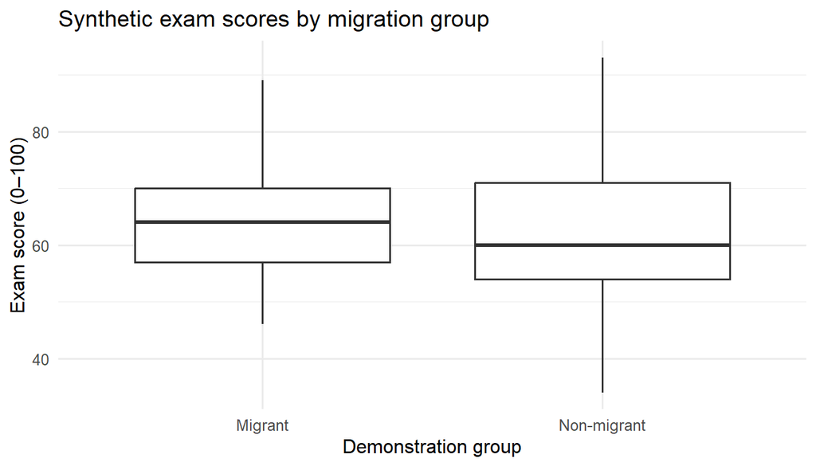

```r
ggplot(analysis_data, aes(x = migration_status, y = exam_score)) +
  geom_boxplot() +
  labs(
    title = "Synthetic exam scores by migration group",
    x = "Demonstration group",
    y = "Exam score (0–100)"
  )
```

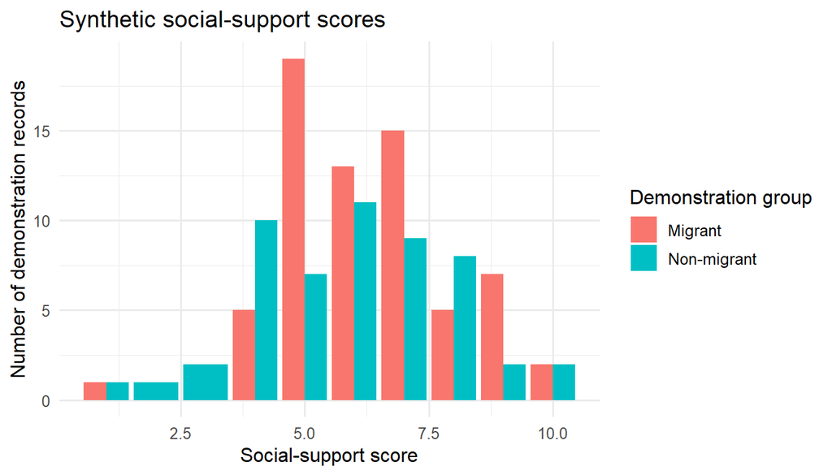

```r
ggplot(analysis_data, aes(x = social_support, fill = migration_status)) +
  geom_bar(position = "dodge") +
  labs(
    title = "Synthetic social-support scores",
    x = "Social-support score",
    y = "Number of demonstration records",
    fill = "Demonstration group"
  )
```

## 6. Group comparison and effect size

```r
score_test <- t.test(exam_score ~ migration_status, data = analysis_data)
score_test
```

```
##
##  Welch Two Sample t-test
##
## data:  exam_score by migration_status
## t = 1.202, df = 97.973, p-value = 0.2323
## alternative hypothesis: true difference in means between group Migrant and group Non-migrant is not equal to 0
## 95 percent confidence interval:
##  -1.656725  6.746559
## sample estimates:
##     mean in group Migrant mean in group Non-migrant
##                  64.86567                  62.32075
```

```r
# Effect-size estimate for the group difference
effectsize::cohens_d(exam_score ~ migration_status, data = analysis_data)
```

```
## Cohen's d |        95% CI
## -------------------------
## 0.23      | [-0.14, 0.59]
##
## - Estimated using pooled SD.
```

## 7. Categorical association

```r
association_table <- table(analysis_data$migration_status, analysis_data$sex)
association_table
```

```
##
##               Female Male
##   Migrant         30   37
##   Non-migrant     25   28
```

```r
# Use cautiously when expected cell counts are small
chisq.test(association_table)
```

```
##
##  Pearson's Chi-squared test with Yates' continuity
##  correction
##
## data:  association_table
## X-squared = 0.0059079, df = 1, p-value = 0.9387
```

## 8. Correlation analysis

```r
cor.test(
  analysis_data$social_support,
  analysis_data$exam_score,
  method = "spearman",
  exact = FALSE
)
```

```
##
##  Spearman's rank correlation rho
##
## data:  analysis_data$social_support and analysis_data$exam_score
## S = 291265, p-value = 0.9016
## alternative hypothesis: true rho is not equal to 0
## sample estimates:
##         rho
## -0.01140598
```

```r
numeric_data <- analysis_data %>%
  select(social_support, sense_of_belonging, study_hours, exam_score)
cor(numeric_data, use = "pairwise.complete.obs", method = "spearman")
```

```
##                    social_support sense_of_belonging
## social_support         1.00000000        -0.02988094
## sense_of_belonging    -0.02988094         1.00000000
## study_hours            0.02071426         0.11935452
## exam_score            -0.01140598         0.10322035
##                    study_hours   exam_score
## social_support     0.020714257 -0.011405985
## sense_of_belonging 0.119354524  0.103220351
## study_hours        1.000000000  0.002678575
## exam_score         0.002678575  1.000000000
```

## 9. Interpretation and limitations

This document demonstrates common steps in a reproducible R workflow: creating and checking data, joining tables, summarising variables, visualising distributions, comparing groups, estimating effect size, testing categorical association, and exploring correlations.

Because the records are synthetic and randomly generated, any numbers or statistical test results produced when knitting this file are **not real research findings**. They should not be cited as evidence about migration, student well-being, or academic performance. A real analysis would also require documented variable definitions, a missing-data plan, appropriate checks of test assumptions, consideration of sampling design, and cautious interpretation of observational associations.

## Reproducibility note

The demonstration data are generated by code in this document, so no external spreadsheet or private dataset is needed. To reproduce the analysis, install the packages used above and knit this R Markdown file in RStudio.